# Pooled 3-Cohort Neuropsych: Spontaneous Reversal (Class 1 Crude)

Minghui (Grace) Wang

2026-07-10

# 0. Overview

## Method

For each test and sex stratum, observed change was calculated from baseline to the first follow-up and annualized by the elapsed follow-up time.

Class 1 thresholds were evaluated at each participant’s exact index age using fixed-effect predictions. For index age *A* and horizon *h*, the model contrast was:

```
Pred(age = A) - Pred(age = A - h)
```

For each horizon:

- expected decline: threshold = `-model_change`;
- expected improvement: threshold = `2 × model_change`;
- no expected change: threshold = 0.

Observed and model-estimated changes were sign-reversed for Trails A and Trails B so that positive values consistently indicate improvement.

Outputs include exclusive counts, cumulative counts, cumulative percentages, and participant-level scatter plots for baseline ages 50–90.

# 1. Setup

## 1.1 Output folders

```r
SAMPLE <- "2visit"
covariates <- NULL
source("R/setup_analysis_sample.R")

model_tag <- if (SAMPLE == "2visit") "crude_2visit" else "crude"
dir_tag   <- if (SAMPLE == "2visit") "_2visit" else ""

class1_fits_file <- paste0(
  "pooled3_",
  model_tag,
  "_class1_fits.rds"
)

plot_dir     <- paste0(
  "../output/plots/pooled3_06_spontaneous_reversal_class1_crude", dir_tag
)
table_dir    <- paste0(
  "../output/tables/pooled3_06_spontaneous_reversal_class1_crude", dir_tag
)
dir.create(plot_dir,     recursive = TRUE, showWarnings = FALSE)
dir.create(table_dir,    recursive = TRUE, showWarnings = FALSE)
```

## 1.2 Load saved Class 1 models

```r
model_rds_dir <- "../output/models"

class1_fits <- readRDS(file.path(model_rds_dir, class1_fits_file))

class1_fits_success <- class1_fits |>
  filter(fit_success)

cat(
  "Loaded", nrow(class1_fits_success),
  "successfully fitted Class 1 model strata\n"
)
```

```
## Loaded 28 successfully fitted Class 1 model strata
```

```r
class1_fits_success |>
  select(test, sex_label, n_obs, n_subjects, subject_random_slope_used) |>
  knitr::kable()
```

| test | sex_label | n_obs | n_subjects | subject_random_slope_used |
| --- | --- | --- | --- | --- |
| coding_correct | Women | 1800 | 874 | TRUE |
| coding_correct | Men | 1599 | 775 | TRUE |
| dsb | Women | 5683 | 2003 | TRUE |
| dsb | Men | 4186 | 1553 | TRUE |
| dsf | Women | 5789 | 2037 | TRUE |
| dsf | Men | 4260 | 1573 | TRUE |
| lmd | Women | 7244 | 2313 | TRUE |
| lmd | Men | 5537 | 1863 | TRUE |
| lmi | Women | 7298 | 2319 | TRUE |
| lmi | Men | 5570 | 1870 | TRUE |
| lmr | Women | 6164 | 1975 | TRUE |
| lmr | Men | 4715 | 1580 | TRUE |
| pasd | Women | 6009 | 1936 | TRUE |
| pasd | Men | 4612 | 1549 | TRUE |
| pasi | Women | 6715 | 2115 | TRUE |
| pasi | Men | 5063 | 1678 | TRUE |
| pasr | Women | 3419 | 1428 | TRUE |
| pasr | Men | 2663 | 1128 | TRUE |
| trailsa | Women | 6109 | 2027 | TRUE |
| trailsa | Men | 4925 | 1698 | TRUE |
| trailsb | Women | 5861 | 1968 | TRUE |
| trailsb | Men | 4769 | 1662 | TRUE |
| vrd | Women | 6988 | 2266 | TRUE |
| vrd | Men | 5471 | 1848 | TRUE |
| vri | Women | 7038 | 2275 | TRUE |
| vri | Men | 5514 | 1858 | TRUE |
| vrr | Women | 6702 | 2149 | TRUE |
| vrr | Men | 5150 | 1708 | TRUE |

## 1.3 Test dictionary

```r
test_dictionary <- make_pooled_test_dictionary(model_ready_pool)
test_dictionary |> knitr::kable()
```

| test | test_label | xprize_subdomain | range |
| --- | --- | --- | --- |
| dsf | Digit Span Forward | Attention | 0-9 |
| dsb | Digit Span Backward | Executive Function & Processing | 0-8 |
| trailsb | Trail Making Test Part B | Executive Function & Processing | 0.32-10.00 minutes; maximum time set at 10 minutes |
| lmd | Logical Memory, delayed recall | Memory | 0-23 |
| lmi | Logical Memory, immediate recall | Memory | 0-23 |
| lmr | Logical Memory, recognition | Memory | 0-11 |
| pasd | Paired Associates, delayed recall | Memory | 0-10 |
| pasi | Paired Associates, immediate recall | Memory | 0-21 |
| pasr | Paired Associates, recognition | Memory | 0-10 |
| coding_correct | WAIS-IV Coding, total correct | Psychomotor | 0-119 |
| trailsa | Trail Making Test Part A | Psychomotor | 0.32-10.00 minutes; maximum time set at 10 minutes |
| vrd | Visual Reproductions, delayed recall | Visual Learning | 0-14 |
| vri | Visual Reproductions, immediate recall | Visual Learning | 0-14 |
| vrr | Visual Reproductions, recognition | Visual Learning | 0-14 |

## 1.4 Score direction

Trails A and Trails B are scored as completion time (higher = worse). For these tests, both observed and model changes are sign-flipped so that positive always means improvement.

```r
test_dictionary |>
  mutate(
    score_direction = if_else(test %in% higher_is_worse_tests, -1L, 1L),
    direction_note  = if_else(
      score_direction == -1L,
      "Higher is worse (completion time); sign-flipped",
      "Higher is better"
    )
  ) |>
  select(test, test_label, score_direction, direction_note) |>
  knitr::kable()
```

| test | test_label | score_direction | direction_note |
| --- | --- | --- | --- |
| dsf | Digit Span Forward | 1 | Higher is better |
| dsb | Digit Span Backward | 1 | Higher is better |
| trailsb | Trail Making Test Part B | -1 | Higher is worse (completion time); sign-flipped |
| lmd | Logical Memory, delayed recall | 1 | Higher is better |
| lmi | Logical Memory, immediate recall | 1 | Higher is better |
| lmr | Logical Memory, recognition | 1 | Higher is better |
| pasd | Paired Associates, delayed recall | 1 | Higher is better |
| pasi | Paired Associates, immediate recall | 1 | Higher is better |
| pasr | Paired Associates, recognition | 1 | Higher is better |
| coding_correct | WAIS-IV Coding, total correct | 1 | Higher is better |
| trailsa | Trail Making Test Part A | -1 | Higher is worse (completion time); sign-flipped |
| vrd | Visual Reproductions, delayed recall | 1 | Higher is better |
| vri | Visual Reproductions, immediate recall | 1 | Higher is better |
| vrr | Visual Reproductions, recognition | 1 | Higher is better |

# 2. Observed change (baseline to first follow-up)

Observed change was calculated from baseline to the first follow-up and annualized by the elapsed follow-up time. Records were restricted to index baseline ages 50–90 before calculating the model-based thresholds.

## 2.1 Compute per stratum

```r
class1_with_obs <- class1_fits_success |>
  mutate(
    obs = map(
      data,
      \(data_x) {
        data_x |>
          compute_obs_change() |>                # defined in R/spontaneous_reversal_functions.R.
          restrict_reversal_baseline_age()
      }
    )
  )

subject_obs <- class1_with_obs |>
  select(test, sex_label, obs) |>
  unnest(obs)

cat(
  "Observed change computed for",
  n_distinct(subject_obs$dbgap_subject_id),
  "unique subjects across",
  n_distinct(subject_obs$test), "tests\n"
)
```

```
## Observed change computed for 3495 unique subjects across 14 tests
```

## 2.2 Follow-up intervals

```r
subject_obs |>
  group_by(test, sex_label) |>
  summarise(
    n = n(),
    median_fu_years = median(followup_years),
    iqr_lo = quantile(followup_years, 0.25),
    iqr_hi = quantile(followup_years, 0.75),
    max_fu_years = max(followup_years),
    .groups = "drop"
  ) |>
  knitr::kable(digits = 1)
```

| test | sex_label | n | median_fu_years | iqr_lo | iqr_hi | max_fu_years |
| --- | --- | --- | --- | --- | --- | --- |
| coding_correct | Women | 561 | 5.2 | 4.1 | 6.0 | 8.8 |
| coding_correct | Men | 485 | 5.2 | 4.1 | 5.9 | 9.0 |
| dsb | Women | 1630 | 5.3 | 2.4 | 7.0 | 20.3 |
| dsb | Men | 1231 | 5.3 | 2.9 | 7.0 | 17.0 |
| dsf | Women | 1662 | 5.3 | 2.4 | 7.0 | 20.3 |
| dsf | Men | 1252 | 5.3 | 2.9 | 7.0 | 17.0 |
| lmd | Women | 1850 | 5.8 | 3.4 | 6.9 | 19.0 |
| lmd | Men | 1468 | 5.9 | 3.9 | 6.8 | 17.1 |
| lmi | Women | 1859 | 5.8 | 3.4 | 6.9 | 20.3 |
| lmi | Men | 1477 | 5.9 | 3.8 | 6.8 | 17.1 |
| lmr | Women | 1574 | 5.8 | 3.1 | 6.8 | 19.0 |
| lmr | Men | 1266 | 5.9 | 4.0 | 6.8 | 17.1 |
| pasd | Women | 1542 | 5.8 | 3.2 | 6.8 | 19.0 |
| pasd | Men | 1241 | 5.9 | 4.1 | 6.8 | 17.1 |
| pasi | Women | 1744 | 5.8 | 3.3 | 6.9 | 19.0 |
| pasi | Men | 1382 | 5.9 | 3.8 | 6.8 | 17.4 |
| pasr | Women | 1139 | 5.9 | 3.6 | 7.2 | 13.1 |
| pasr | Men | 898 | 5.8 | 4.3 | 7.2 | 12.0 |
| trailsa | Women | 1567 | 5.9 | 3.6 | 6.8 | 19.0 |
| trailsa | Men | 1301 | 5.9 | 4.1 | 6.8 | 18.0 |
| trailsb | Women | 1526 | 5.9 | 3.6 | 6.9 | 19.0 |
| trailsb | Men | 1275 | 5.9 | 4.1 | 6.8 | 18.0 |
| vrd | Women | 1803 | 5.9 | 3.5 | 6.9 | 19.0 |
| vrd | Men | 1450 | 5.9 | 3.9 | 6.8 | 17.1 |
| vri | Women | 1816 | 5.9 | 3.5 | 6.9 | 19.0 |
| vri | Men | 1460 | 5.9 | 3.9 | 6.8 | 17.1 |
| vrr | Women | 1747 | 5.8 | 3.4 | 6.9 | 19.0 |
| vrr | Men | 1393 | 5.9 | 3.9 | 6.8 | 17.1 |

# 3. Model-estimated changes (Class 1, exact age)

Class 1 model changes were evaluated directly from the fitted fixed effects at each participant’s exact index age. The backward-age contrast follows the definition in the Method section.

## 3.1 Compute per stratum

```r
class1_with_mc <- class1_with_obs |>
  mutate(
    model_changes = pmap(
      list(model, obs),
      function(model_x, obs_x) {
        compute_model_change_class1(model_x, unique(obs_x$baseline_age))
      }
    )
  )
```

# 4. Reversal classification

Observed changes were joined to the exact-age Class 1 contrasts before applying the horizon-specific reversal thresholds.

## 4.1 Classify

```r
reversal_subject_level <- class1_with_mc |>
  mutate(
    classified = pmap(
      list(obs, model_changes, test, sex_label),
      function(obs_x, mc_x, test_x, sex_x) {
        obs_x |>
          left_join(mc_x, by = "baseline_age") |>
          mutate(test = test_x, sex_label = sex_x) |>
          classify_reversal()
      }
    )
  ) |>
  select(classified) |>
  unnest(classified) |>
  restrict_reversal_baseline_age()

cat(
  "Classified", nrow(reversal_subject_level),
  "participant-test combinations (baseline age 50-90) across",
  n_distinct(reversal_subject_level$test), "tests\n"
)
```

```
## Classified 39599 participant-test combinations (baseline age 50-90) across 14 tests
```

## 4.2 Reversal summary

```r
reversal_subject_level |>
  group_by(test, sex_label) |>
  summarise(
    n = n(),
    n_any_rev = sum(max_reversal_year > 0),
    pct_any = 100 * mean(max_reversal_year > 0),
    n_rev_5  = sum(reversal_5yr),
    n_rev_10 = sum(reversal_10yr),
    n_rev_15 = sum(reversal_15yr),
    n_rev_20 = sum(reversal_20yr),
    .groups = "drop"
  ) |>
  knitr::kable(digits = 1)
```

| test | sex_label | n | n_any_rev | pct_any | n_rev_5 | n_rev_10 | n_rev_15 | n_rev_20 |
| --- | --- | --- | --- | --- | --- | --- | --- | --- |
| coding_correct | Women | 561 | 5 | 0.9 | 5 | 1 | 0 | 0 |
| coding_correct | Men | 485 | 19 | 3.9 | 19 | 6 | 3 | 5 |
| dsb | Women | 1630 | 381 | 23.4 | 381 | 331 | 274 | 224 |
| dsb | Men | 1231 | 313 | 25.4 | 313 | 273 | 244 | 232 |
| dsf | Women | 1662 | 380 | 22.9 | 380 | 318 | 284 | 261 |
| dsf | Men | 1252 | 280 | 22.4 | 280 | 240 | 219 | 205 |
| lmd | Women | 1850 | 416 | 22.5 | 388 | 205 | 126 | 88 |
| lmd | Men | 1468 | 377 | 25.7 | 360 | 201 | 133 | 107 |
| lmi | Women | 1859 | 416 | 22.4 | 385 | 212 | 131 | 106 |
| lmi | Men | 1477 | 372 | 25.2 | 352 | 204 | 141 | 111 |
| lmr | Women | 1574 | 444 | 28.2 | 443 | 305 | 217 | 166 |
| lmr | Men | 1266 | 438 | 34.6 | 438 | 318 | 234 | 175 |
| pasd | Women | 1542 | 242 | 15.7 | 242 | 116 | 74 | 77 |
| pasd | Men | 1241 | 341 | 27.5 | 340 | 251 | 175 | 117 |
| pasi | Women | 1744 | 439 | 25.2 | 404 | 290 | 206 | 146 |
| pasi | Men | 1382 | 382 | 27.6 | 363 | 291 | 230 | 184 |
| pasr | Women | 1139 | 25 | 2.2 | 25 | 11 | 5 | 4 |
| pasr | Men | 898 | 56 | 6.2 | 56 | 44 | 32 | 28 |
| trailsa | Women | 1567 | 36 | 2.3 | 36 | 18 | 6 | 2 |
| trailsa | Men | 1301 | 37 | 2.8 | 37 | 10 | 3 | 3 |
| trailsb | Women | 1526 | 75 | 4.9 | 39 | 17 | 27 | 31 |
| trailsb | Men | 1275 | 48 | 3.8 | 25 | 16 | 21 | 26 |
| vrd | Women | 1803 | 319 | 17.7 | 305 | 182 | 148 | 174 |
| vrd | Men | 1450 | 347 | 23.9 | 330 | 252 | 197 | 136 |
| vri | Women | 1816 | 319 | 17.6 | 292 | 162 | 142 | 172 |
| vri | Men | 1460 | 296 | 20.3 | 274 | 168 | 154 | 166 |
| vrr | Women | 1747 | 394 | 22.6 | 394 | 327 | 292 | 252 |
| vrr | Men | 1393 | 360 | 25.8 | 360 | 293 | 218 | 168 |

# 5. Table 4 outputs

Participant-level spontaneous reversal classifications were summarized by baseline-age group in three formats:

- **Exclusive count:** maximum qualifying horizon;
- **Cumulative count:** maximum qualifying horizon at or above each column;
- **Cumulative percentage:** cumulative count divided by N.

## 5.1 Table 4 (exclusive form)

```r
table4_exclusive <- make_table4(
  reversal_subject_level, test_dictionary, form = "exclusive"
)

table4_exclusive |>
  filter(test == "lmd") |>
  select(-xprize_subdomain, -test, -test_label, -age_bin) |>
  knitr::kable()
```

| sex_label | age_label | N | N reversal 5yr | N reversal 10yr | N reversal 15yr | N reversal 20yr |
| --- | --- | --- | --- | --- | --- | --- |
| Women | 50-54 | 342 | 20 | 2 | 0 | 0 |
| Women | 55-59 | 334 | 56 | 19 | 0 | 2 |
| Women | 60-64 | 251 | 69 | 34 | 9 | 2 |
| Women | 65-69 | 224 | 0 | 22 | 46 | 13 |
| Women | 70-74 | 201 | 2 | 0 | 0 | 44 |
| Women | 75-79 | 176 | 6 | 2 | 0 | 9 |
| Women | 80-84 | 186 | 11 | 13 | 1 | 13 |
| Women | 85-90 | 136 | 9 | 6 | 1 | 5 |
| Men | 50-54 | 277 | 20 | 2 | 0 | 0 |
| Men | 55-59 | 299 | 48 | 5 | 0 | 0 |
| Men | 60-64 | 220 | 63 | 26 | 4 | 0 |
| Men | 65-69 | 209 | 4 | 41 | 29 | 12 |
| Men | 70-74 | 203 | 0 | 0 | 8 | 52 |
| Men | 75-79 | 133 | 7 | 0 | 0 | 24 |
| Men | 80-84 | 81 | 3 | 2 | 1 | 11 |
| Men | 85-90 | 46 | 5 | 2 | 0 | 8 |

```r
# write_table4_workbook() is defined in workbook_writers.R
# make_output_name() is defined in helpers.R.

write_csv(
  table4_exclusive,
  file.path(
    table_dir,
    make_output_name(
      paste0("xprize_pooled3_", model_tag, "_class1_table4_exclusive"),
      "csv"
    )
  )
)

table4_excl_xlsx <- file.path(
  table_dir,
  make_output_name(
    paste0("xprize_pooled3_", model_tag, "_class1_table4_exclusive"),
    "xlsx"
  )
)
write_table4_workbook(table4_exclusive, table4_excl_xlsx, form = "exclusive")
```

## 5.2 Table 4 (cumulative form)

```r
table4_cumulative <- make_table4(
  reversal_subject_level, test_dictionary, form = "cumulative"
)

# Preview one test.
table4_cumulative |>
  filter(test == "lmd") |>
  select(-xprize_subdomain, -test, -test_label, -age_bin) |>
  knitr::kable()
```

| sex_label | age_label | N | N reversal 5yr | N reversal 10yr | N reversal 15yr | N reversal 20yr |
| --- | --- | --- | --- | --- | --- | --- |
| Women | 50-54 | 342 | 22 | 2 | 0 | 0 |
| Women | 55-59 | 334 | 77 | 21 | 2 | 2 |
| Women | 60-64 | 251 | 114 | 45 | 11 | 2 |
| Women | 65-69 | 224 | 81 | 81 | 59 | 13 |
| Women | 70-74 | 201 | 46 | 44 | 44 | 44 |
| Women | 75-79 | 176 | 17 | 11 | 9 | 9 |
| Women | 80-84 | 186 | 38 | 27 | 14 | 13 |
| Women | 85-90 | 136 | 21 | 12 | 6 | 5 |
| Men | 50-54 | 277 | 22 | 2 | 0 | 0 |
| Men | 55-59 | 299 | 53 | 5 | 0 | 0 |
| Men | 60-64 | 220 | 93 | 30 | 4 | 0 |
| Men | 65-69 | 209 | 86 | 82 | 41 | 12 |
| Men | 70-74 | 203 | 60 | 60 | 60 | 52 |
| Men | 75-79 | 133 | 31 | 24 | 24 | 24 |
| Men | 80-84 | 81 | 17 | 14 | 12 | 11 |
| Men | 85-90 | 46 | 15 | 10 | 8 | 8 |

```r
write_csv(
  table4_cumulative,
  file.path(
    table_dir,
    make_output_name(
      paste0("xprize_pooled3_", model_tag, "_class1_table4_cumulative"),
      "csv"
    )
  )
)

table4_cumul_xlsx <- file.path(
  table_dir,
  make_output_name(
    paste0("xprize_pooled3_", model_tag, "_class1_table4_cumulative"),
    "xlsx"
  )
)
write_table4_workbook(table4_cumulative, table4_cumul_xlsx, form = "cumulative")
```

## 5.3 Table 4 (cumulative percentage)

```r
table4_cumulative_pct <- make_table4(
  reversal_subject_level, test_dictionary, form = "cumulative_pct"
)

# Preview one test (values are proportions of N).
table4_cumulative_pct |>
  filter(test == "lmd") |>
  select(-xprize_subdomain, -test, -test_label, -age_bin) |>
  knitr::kable(digits = 3)
```

| sex_label | age_label | N | N reversal 5yr | N reversal 10yr | N reversal 15yr | N reversal 20yr |
| --- | --- | --- | --- | --- | --- | --- |
| Women | 50-54 | 342 | 0.064 | 0.006 | 0.000 | 0.000 |
| Women | 55-59 | 334 | 0.231 | 0.063 | 0.006 | 0.006 |
| Women | 60-64 | 251 | 0.454 | 0.179 | 0.044 | 0.008 |
| Women | 65-69 | 224 | 0.362 | 0.362 | 0.263 | 0.058 |
| Women | 70-74 | 201 | 0.229 | 0.219 | 0.219 | 0.219 |
| Women | 75-79 | 176 | 0.097 | 0.062 | 0.051 | 0.051 |
| Women | 80-84 | 186 | 0.204 | 0.145 | 0.075 | 0.070 |
| Women | 85-90 | 136 | 0.154 | 0.088 | 0.044 | 0.037 |
| Men | 50-54 | 277 | 0.079 | 0.007 | 0.000 | 0.000 |
| Men | 55-59 | 299 | 0.177 | 0.017 | 0.000 | 0.000 |
| Men | 60-64 | 220 | 0.423 | 0.136 | 0.018 | 0.000 |
| Men | 65-69 | 209 | 0.411 | 0.392 | 0.196 | 0.057 |
| Men | 70-74 | 203 | 0.296 | 0.296 | 0.296 | 0.256 |
| Men | 75-79 | 133 | 0.233 | 0.180 | 0.180 | 0.180 |
| Men | 80-84 | 81 | 0.210 | 0.173 | 0.148 | 0.136 |
| Men | 85-90 | 46 | 0.326 | 0.217 | 0.174 | 0.174 |

```r
write_csv(
  table4_cumulative_pct,
  file.path(
    table_dir,
    make_output_name(
      paste0("xprize_pooled3_", model_tag, "_class1_table4_cumulative_pct"),
      "csv"
    )
  )
)

table4_cumul_pct_xlsx <- file.path(
  table_dir,
  make_output_name(
    paste0("xprize_pooled3_", model_tag, "_class1_table4_cumulative_pct"),
    "xlsx"
  )
)
write_table4_workbook(
  table4_cumulative_pct, table4_cumul_pct_xlsx, form = "cumulative_pct"
)
```

# 6. Scatter plots

Scatter plots display the observations underlying Table 4. The x-axis shows index baseline age, and the y-axis shows direction-adjusted annualized observed change. Points are colored by maximum qualifying reversal horizon and panels are separated by sex.

## 6.1 Check one test

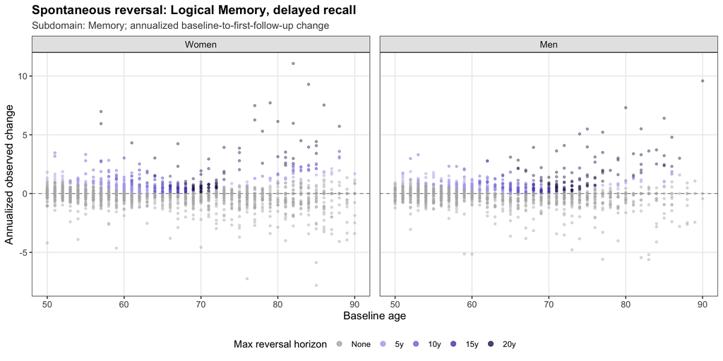

```r
plot_reversal_scatter(reversal_subject_level, test_dictionary, "lmd")
```

## 6.2 Save all tests

```r
scatter_order <- reversal_subject_level |>
  distinct(test) |>
  left_join(
    test_dictionary |> select(test, xprize_subdomain),
    by = "test"
  ) |>
  arrange(xprize_subdomain, test)

walk2(
  scatter_order$xprize_subdomain,
  scatter_order$test,
  function(subdomain_x, test_x) {

    p <- plot_reversal_scatter(
      reversal_subject_level, test_dictionary, test_x
    )

    subdomain_file <- subdomain_x |>
      str_to_lower() |>
      str_replace_all("&", "and") |>
      str_replace_all("[^a-z0-9]+", "_") |>
      str_replace_all("_+", "_") |>
      str_replace_all("^_|_$", "")

    test_file <- test_x |>
      str_to_lower() |>
      str_replace_all("[^a-z0-9]+", "_") |>
      str_replace_all("_+", "_") |>
      str_replace_all("^_|_$", "")

    ggsave(
      filename = file.path(
        plot_dir,
        paste0(
          "class1_reversal_scatter_",
          subdomain_file, "_", test_file,
          "_", output_suffix, ".pdf"
        )
      ),
      plot = p,
      width = 12,
      height = 6
    )
  }
)

cat("Scatter plots saved to:", plot_dir, "\n")
```

```
## Scatter plots saved to: ../output/plots/pooled3_06_spontaneous_reversal_class1_crude_2visit
```